# Séance 3 : Aide-Mémoire

Cécile Armand

2025-10-15

# Définitions

## Matrices

Les matrices d’adjacence et matrices d’incidence sont deux façons de représenter des graphes, mais elles servent des objectifs différents selon la nature du réseau — notamment s’il est simple ou bipartite. Voici un tableau synthétique comparant leurs caractéristiques et différences :

| Caractéristique | **Adjacency Matrix** | **Incidence Matrix** |
| --- | --- | --- |
| Forme | Carrée (*n × n*) | Rectangulaire (*n × m*) |
| Représente | Connexions entre **nœuds** | Connexions entre **nœuds et arêtes** |
| Utile pour | Calculs de centralité classiques | Représentation explicite des liens individuels |
| Adaptée aux graphes | Simples, orientés, pondérés | Bipartites, multigraphes, graphe orienté/non |
| Nombre de colonnes | = nombre de nœuds | = nombre de liens/arêtes |

## Mesures globales

**Connexité**: Un graphe connexe est un graphe dans lequel il existe un chemin entre chaque paire de sommets. Autrement dit, aucun sommet n’est isolé : on peut aller de n’importe quel sommet à n’importe quel autre, en suivant les arêtes du graphe. Dans igraph, on peut évaluer la connexité d’un graphe avec deux fonctions :

- `is_connected(g)` : pour tester la connexité du graphe. Renvoie TRUE si le graphe est entièrement connexe, FALSE sinon.
- `components(g)` : pour décomposer le graphe en composantes connexes. La fonction renvoie une liste des composantes (sous-ensembles connexes). Elle est utile pour savoir combien de “blocs isolés” le graphe contient.

## Centralités

Le tableau ci-joint synthétise les principales mesures de centralité disponibles avec igraph. Les plus couramment utilisées sont illustrées ci-dessous.

| Centralité | Fonction `igraph` | Description |
| --- | --- | --- |
| **Degré** | `degree()` | Nombre d’arêtes connectées à un sommet (entrantes, sortantes ou totales). |
| **Intermédiarité (nœuds)** | `betweenness()` | Compte le nombre de plus courts chemins passant par un sommet. |
| **Intermédiarité (arêtes)** | `edge_betweenness()` | Compte le nombre de plus courts chemins passant par une arête. |
| **Proximité** | `closeness()` | Inverse de la somme des distances d’un sommet aux autres (plus petite = plus central). |
| **Éigenvector (valeur propre)** | `eigen_centrality()` | Tient compte non seulement du nombre de voisins, mais aussi de leur influence. |
| **Centralité de Katz** | `alpha_centrality()` | Variante pondérée de la centralité de degré, intégrant les chemins indirects (et orientés). |
| **Centralité de Bonacich** | `power_centrality()` | Généralisation de la centralité de Katz avec paramètre d’influence. |
| **PageRank** | `page_rank()` | Modélise la probabilité de visite d’un sommet par un “surfeur aléatoire” (comme Google). |
| **Rayonnement (hub/authority)** | `hub_score()` / `authority_score()` | Score des hubs (émetteurs forts) et des autorités (récepteurs forts), selon l’algorithme HITS. |
| **Rayonnement total (directed)** | `subgraph_centrality()` | Nombre de sous-graphes auxquels un nœud participe (rarement utilisé car coûteux). |

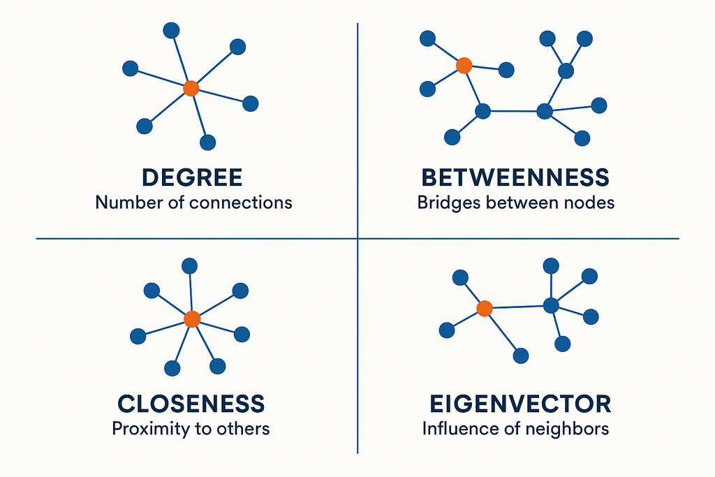

# Principales fonctions de igraph

Voici une liste des principales fonctions et mesures disponibles dans le package **`igraph`** pour décrire et analyser un réseau (graphe). Elles couvrent les **propriétés globales**, les **caractéristiques des sommets (noeuds) et arêtes (liens)**, ainsi que les **outils de détection de structures** (communautés, etc.).

## 1. **Statistiques globales du réseau**

| Fonction | Description |
| --- | --- |
| `gorder(graph)` | Nombre de **sommets** (ordre du graphe) |
| `gsize(graph)` | Nombre d’**arêtes** (taille du graphe) |
| `is_connected(graph)` | Le graphe est-il connexe ? |
| `components(graph)` | Détection des **composantes connexes** |
| `diameter(graph)` | **Diamètre** du graphe (plus longue plus courte distance) |
| `mean_distance(graph)` | **Distance moyenne** entre les nœuds |
| `edge.density(graph)` | **Densité** du graphe |
| `transitivity(graph, type = "global")` | **Coefficient de clustering global** |
| `reciprocity(graph)` | **Réciprocité** (dans les graphes orientés) |

## 2. **Mesures centrées sur les sommets (nœuds)**

| Fonction | Description |
| --- | --- |
| `degree(graph, mode = "all")` | **Degré** des nœuds (nombre de liens) |
| `strength(graph)` | **Force** pondérée (somme des poids des liens) |
| `closeness(graph)` | **Centralité de proximité** |
| `betweenness(graph)` | **Centralité d’intermédiarité** |
| `eigen_centrality(graph)` | **Centralité vectorielle propre** |
| `page_rank(graph)` | **PageRank** (influence d’un nœud) |
| `constraint(graph)` | **Contraintes structurelles** (théorie de Burt) |
| `hub_score(graph)` / `authority_score(graph)` | Score de **hub** / **autorité** (HITS algorithm) |
| `neighborhood(graph, order = 1)` | Renvoie les **voisins directs** (ou à n pas) d’un sommet |

## 3. **Mesures sur les arêtes**

| Fonction | Description |
| --- | --- |
| `edge_betweenness(graph)` | **Centr. d’intermédiarité** des arêtes |
| `E(graph)$weight` | Accès aux **poids** des arêtes |
| `delete_edges(graph, edges)` | Supprimer des arêtes |

## 4. **Distances et chemins**

| Fonction | Description |
| --- | --- |
| `shortest_paths(graph, from, to)` | **Plus court chemin** entre deux nœuds |
| `distances(graph)` | **Matrice des distances** entre tous les nœuds |
| `mean_distance(graph)` | **Distance moyenne** |
| `diameter(graph)` | **Diamètre** du graphe |
| `path_length_hist(graph)` | Histogramme des longueurs de chemins |

## 5. **Détection de communautés et structures**

| Fonction | Description |
| --- | --- |
| `cluster_walktrap(graph)` | Détection de **communautés** par marches aléatoires |
| `cluster_louvain(graph)` | **Méthode de Louvain** (optimisation de modularité) |
| `cluster_fast_greedy(graph)` | Regroupement hiérarchique **greedy** |
| `membership()` | Renvoie les **groupes d’appartenance** |
| `modularity(graph, membership)` | Calcule la **modularité** d’une partition |

## 6. **Visualisation rapide**

| Fonction | Description |
| --- | --- |
| `plot(graph)` | Visualisation de base |
| `plot.igraph(graph, vertex.size=, edge.width=)` | Ajout d’attributs visuels |
| `layout_with_fr()` | Algorithme de **Fruchterman-Reingold** |
| `layout_with_kk()` | **Kamada-Kawai** |
| `layout_as_tree()` | Arborescence |
| `set.seed()` | Pour reproductibilité des dispositions |

## 7. **Accès, filtrage et manipulation**

| Fonction | Description |
| --- | --- |
| `V(graph)` / `E(graph)` | Accès aux **nœuds** / **arêtes** |
| `degree_distribution(graph)` | Distribution des degrés |
| `subgraph.edges(graph, edges)` | Extraire un **sous-graphe** |
| `induced_subgraph(graph, vids)` | Sous-graphe à partir d’un ensemble de sommets |
| `delete_vertices(graph, v)` | Supprimer un ou plusieurs sommets |

## Sauvegarde & export

| Fonction | Description |
| --- | --- |
| `as_data_frame(graph, what = "edges")` | Convertir en **edge list** |
| `write_graph(graph, file = "mon_graphe.graphml", format = "graphml")` | Exporter pour **Gephi** ou **Cytoscape** |